# Prueba de evaluación R

Ivonne Yáñez Mendoza

##### Módulo: Programacion R

##### Profesor: Jose Luis Brita-Paja

##### Master en big data & business analytics, Universidad Complutense de Madrid

##### 26 de abril de 2022

**Pregunta 1**

1. Generar todos los números que entran en el sorteo de la ONCE y mostrarlos con los cuatro dígitos.

```r
# Se genera el dato para trabajar
numeros <- c(formatC(0000:9999, width = 4, flag = '0' ))

# El resultado
resultado <- sapply(numeros, function(x)
          sum( as.numeric(unlist(strsplit(as.character(x), split=""))) ))

ordenado <- sort.int(resultado, decreasing = TRUE)
```

2. ¿Cuál es la suma de los números de un boleto que más se repite?

```r
mas_repetido <- tail(names(sort(table(resultado))), 1)
sprintf("La suma de los numeros de un boleto que mas se repite es %s. ",
        mas_repetido)
```

```
## [1] "La suma de los numeros de un boleto que mas se repite es 18. "
```

**Pregunta 2**

1. Leer los archivos “datos_provincias.csv”, “CodProv.txt* y”CodCCAA.dat “. Añade el código de la comunidad autónoma al fichero”datos_provincias.csv” (no manualmente).

```r
library(kableExtra)
# Paso 1 leer los archivos

cod_ccaa <- read.csv("CodCCAA.csv")
datos_provincias <- data.frame(read.csv("datos_provincias.csv"))
cod_provincias <- data.frame(read.table(file = "CodProv.txt", sep=",",
                  header = TRUE, row.names = NULL))

# Paso 2 se elimina la ES de la columna Codigo del data frame cod_provincias
cod_provincias$Código <- sub("^(\\w+)-", "", cod_provincias$Código)

# Con merge se une tanto el data frame cod_provincias como datos provincias
# para traer el codigo de la comunidad autonoma que corresponde

base_graficos <- merge(cod_provincias, datos_provincias, by.x = "Código", by.y = "provincia_iso", all.y = TRUE)
```

2. Selecciona los datos de la comunidad autónoma que te corresponda. Para saber cuál es tu comunidad autónoma realiza la siguiente operación

```r
# DNI o Pasaporte mod 17 por ejemplo (12345678 %% 17 = 6 → Castilla y León)

# Paso 2 seleccionar los datos de la comunidad autonoma que me corresponde.

dni <- 169728542
dni_provincias <- dni %% 17

# Según este cálculo la provincia asignada es PV, pais vasco, se filtra segun
# el código de la comunidad autónoma"
viscaya <- subset(base_graficos, Comunidad.autónoma == "PV")
```

**Gráficos**

3. Realizar un gráfico que muestre adecuadamente la evolución de los casos nuevos. Justifica el gráfico elegido. Nota: Elegí este tipo de gráfico pues muestra de una forma visual el aumento y decremento de los picos de casos Covid para el periodo señalado.

```r
datos <- viscaya

# Con los datos de Viscaya se genera el gráfico
datos$fecha <- as.Date(datos$fecha)
datos <- datos[order(datos$fecha),]


x <- datos$fecha
y <- datos$num_casos


g <- aggregate(y, by=list(casos=x), FUN=sum)

"grafico 1"
```

```
## [1] "grafico 1"
```

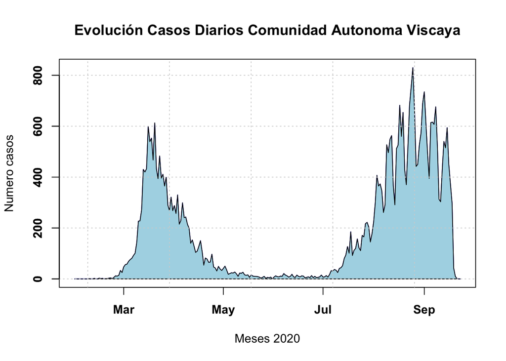

```r
plot(g, type ="l", xlab ="Meses 2020", ylab ="Numero casos", main ="Evolución Casos Diarios Comunidad Autonoma Viscaya", col = "blue", font = 2)
polygon(g, col = "lightblue")
grid()
axis(side= 2, font=2)
```

4. Presenta en único gráfico la evolución de las distintas variables (columnas) por medio de un gráfico de líneas múltiples. Utiliza diferentes colores y añade una leyenda muestre el origen de cada línea.

```r
"grafico 2"
```

```
## [1] "grafico 2"
```

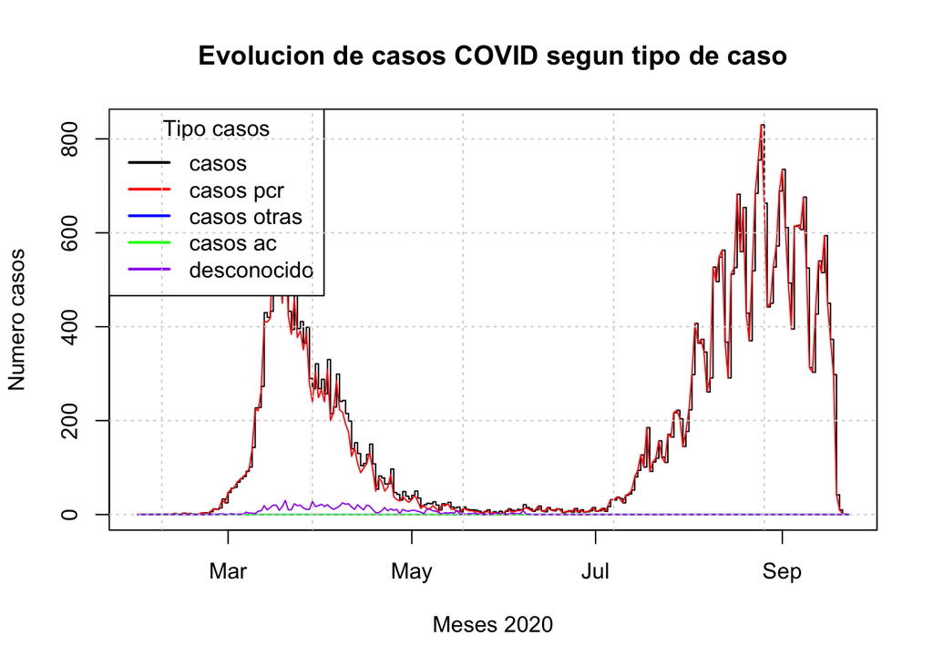

```r
plot(g, type = "s",
     xtat = 'n', ylab = 'Numero casos', xlab = "Meses 2020",
     main = "Evolucion de casos COVID segun tipo de caso", beside = TRUE)


a <- aggregate(datos$num_casos_prueba_pcr, by=list(casos = datos$fecha), FUN = "sum")
b <- aggregate(datos$num_casos_prueba_otras, by= list(casos = datos$fecha), FUN = 'sum')
c <- aggregate(datos$num_casos_prueba_test_ac, by = list(casos = datos$fecha), FUN = 'sum')
d <- aggregate(datos$num_casos_prueba_desconocida, by = list(casos = datos$fecha), FUN = 'sum')
lines(a, col= 'red')
lines(b, col = 'blue')
lines(c, col = 'green')
lines(d,col = 'purple')

legend(x = "topleft",         # Posición
       title = "Tipo casos",
       legend = c("casos", "casos pcr", "casos otras", "casos ac", "desconocido"), # Textos de la leyenda
       lty = c(1),          # Tipo de líneas
       col = c(1, 'red', 'blue', 'green', 'purple'),          # Colores de las líneas
       lwd = 2)
grid()
```

**Pregunta 3**

1. Crear dos data frame de nombres, uno de nombre articulo leyendo la información de “articulo.xlsx” y el otro de nombre descuento que guarde la información de “descuento_aplicar.txt”.

```r
library("xlsx") #Para leer archivos excel

# Paso 1 leer los datos del archivo excel y del archivo txt"
tabla_excel <- read.xlsx("articulo.xlsx", sheetIndex = 1)
descuento <- read.delim("descuento_aplicar.txt")


# Paso 2 transformar la tabla excel y el archivo de texto a un data frame
articulos <- data.frame(tabla_excel)
descuentos <- data.frame(descuento)

# Cálculo de ingreso bruto
articulos$ingreso_bruto <- articulos$PVP * articulos$CANTIDAD

articulos <- articulos[order(articulos$ingreso_bruto, decreasing = TRUE),]
print(head(articulos))
```

```
##    PRODUCTO   PVP CANTIDAD ingreso_bruto
## 5         5 10800     4050      43740000
## 29       29  6600     5800      38280000
## 1         1  5000     6000      30000000
## 36       37  9700     3030      29391000
## 28       28 11500     2000      23000000
## 15       15  5400     4000      21600000
```

2. Crear una variable llamada tipo que clasifique los artículos en los tipos A, B y C en la forma indicada y añadirlo al data frame artículo y calcula, en una única sentencia, el total de ingresos brutos por cada tipo de artículo.

```r
# Calcula deciles para utilizarlos en el cálculo del tipo de descuento

deciles <- quantile(articulos$ingreso_bruto,probs = seq(.1, .9, by = .1))

# Asigna tramo de descuento según ingreso bruto y decil
articulos$tipo <- with(articulos, ifelse(ingreso_bruto >= 6108000, 'A',
                                  ifelse(ingreso_bruto > 1797000 & ingreso_bruto < 6108000, "B",
                                  ifelse(ingreso_bruto <= 1797000, "C", 0))))

# Ordena el data frame de mayor a menor ingreso bruto
articulos <- articulos[order(articulos$ingreso_bruto, decreasing = TRUE), ]
print(head(articulos))
```

```
##    PRODUCTO   PVP CANTIDAD ingreso_bruto tipo
## 5         5 10800     4050      43740000    A
## 29       29  6600     5800      38280000    A
## 1         1  5000     6000      30000000    A
## 36       37  9700     3030      29391000    A
## 28       28 11500     2000      23000000    A
## 15       15  5400     4000      21600000    A
```

3. Unir los dos data frame, articulo y descuento, de forma adecuada, para crear el data frame clientes. Calcular la variable nuevo_pvp = pvp – cantidad a descontar. Suponiendo que el volumen de ventas se mantiene constante dar una estimación del porcentaje de decremento en los ingresos brutos al aplicar los descuentos.

```r
# Se unen los data frame articulos y descuento para crear el df clientes en el paso posterior
articulos2 <- articulos
articulos3 <- merge(articulos, descuento, by.x = "tipo", by.y = "tipo", all.x = TRUE)


# Crea el data frame clientes"

clientes <- articulos3
print(head(clientes))
```

```
##   tipo PRODUCTO   PVP CANTIDAD ingreso_bruto descuento
## 1    A        5 10800     4050      43740000        10
## 2    A       29  6600     5800      38280000        10
## 3    A        1  5000     6000      30000000        10
## 4    A       37  9700     3030      29391000        10
## 5    A       28 11500     2000      23000000        10
## 6    A       15  5400     4000      21600000        10
```

```r
# Calcular la variable nuevo_pvp con el % de descuento correspondiente segun tramo"
clientes$nuevo_pvp <- with(clientes,ifelse(tipo == "A", clientes$PVP * 0.9,
                                             ifelse(tipo == "B", clientes$PVP * 0.85,
                                            ifelse(tipo == "C", clientes$PVP * 0.8, 0))))

# Crea una nueva columna donde calcula el ingreso bruto por artículo con los valores actualizados"
clientes$n_ingreso_bruto <- clientes$CANTIDAD * clientes$nuevo_pvp

# Se realiza el cálculo de decremento"

decremento <- round(100 - ((sum(clientes$n_ingreso_bruto) / sum(clientes$ingreso_bruto)) * 100 ), digits = 2)
paste0("El porcentaje de decremento corresponde a un ", decremento, "%", ".")
```

```
## [1] "El porcentaje de decremento corresponde a un 11.45%."
```

**Pregunta 4**

1. Para la semana S7, calcule el vector (𝑓1,1−𝑓1,𝑓2,1−𝑓2,𝑓3,1−𝑓3,𝑓4,1−𝑓4) donde 𝑓𝑖 es la frecuencia (relativa) de la modalidad 𝑖∈{1,2,3,4} observada en la semana 𝑆7 sobre los 16 sujetos. (Sugerencia: use las funciones tabulate(), cbind(), t()y as.vector()). Ahora, use la función apply() para hacer el mismo cálculo para todas las demás semanas. Almacene el resultado en una matriz.

```r
# Leer el archivo
fichero <- source("matriz.R")
fichero <- fichero[[1]]

print(fichero)
```

```
##       [,1] [,2] [,3] [,4] [,5] [,6] [,7] [,8]
##  [1,]    1    1    1    1    1    1    1    1
##  [2,]    2    1    1    1    1    1    1    2
##  [3,]    3    1    1    1    1    1    2    3
##  [4,]    4    1    1    1    1    1    3    4
##  [5,]    5    1    1    1    1    2    3    3
##  [6,]    6    1    1    1    1    1    1    1
##  [7,]    7    1    1    1    3    4    2    2
##  [8,]    8    1    1    1    1    1    1    1
##  [9,]    9    1    1    1    1    1    1    1
## [10,]   10    1    1    1    1    1    1    4
## [11,]   11    1    1    1    1    1    1    1
## [12,]   12    1    1    1    1    1    1    1
## [13,]   13    1    2    1    3    2    3    4
## [14,]   14    1    1    1    2    2    4    4
## [15,]   15    1    1    1    1    1    1    1
## [16,]   16    1    1    1    1    1    1    1
```

```r
# El primer paso es limpiar y organizar los datos
# La variable base tiene por objetivo contar la cantidad de ocurrencias de los niveles y rellena con 0 en caso de no hallar coincidencias

base <- apply(fichero, 2, function(i) table(factor(i, levels = c(1:4))))

#Se elimina la columna 1 pues no se utilizará para los cálculos y la tabla esta lista para trabajar
base <- base[,-1]
print(base)
```

```
##   [,1] [,2] [,3] [,4] [,5] [,6] [,7]
## 1   16   15   16   13   12   10    8
## 2    0    1    0    1    3    2    2
## 3    0    0    0    2    0    3    2
## 4    0    0    0    0    1    1    4
```

```r
# En una variable se calcula el total de registros que tiene la tabla, son 16
# Es preferible calcularla en caso que se desee reutilizar este script
registros <- nrow(fichero)
print(registros)
```

```
## [1] 16
```

```r
#Se realiza el cálculo de frecuencias relativas para la matriz y se agregan nombres a las columnas

matriz <- base / registros
colnames(matriz) <- c("s1", "s2", "s3", "s4", "s5", "s6", "s7")

print(matriz)
```

```
##   s1     s2 s3     s4     s5     s6    s7
## 1  1 0.9375  1 0.8125 0.7500 0.6250 0.500
## 2  0 0.0625  0 0.0625 0.1875 0.1250 0.125
## 3  0 0.0000  0 0.1250 0.0000 0.1875 0.125
## 4  0 0.0000  0 0.0000 0.0625 0.0625 0.250
```

```r
# Tomando como base la matriz, se crea una nueva para calcular la resta del 1 a las frecuencias

matriz2 <- matrix(unlist(lapply(1, `-`, matriz)), ncol = 7, nrow=4)
row.names(matriz2) <- c("1", "2", "3", "4")
print(matriz2)
```

```
##   [,1]   [,2] [,3]   [,4]   [,5]   [,6]  [,7]
## 1    0 0.0625    0 0.1875 0.2500 0.3750 0.500
## 2    1 0.9375    1 0.9375 0.8125 0.8750 0.875
## 3    1 1.0000    1 0.8750 1.0000 0.8125 0.875
## 4    1 1.0000    1 1.0000 0.9375 0.9375 0.750
```

```r
# Una vez listas ambas matrices es momento de combinarlas para generar la base del gráfico
data <- rbind(matriz, matriz2)
data <- data[ order(as.numeric(row.names(data))), ]
print(data)
```

```
##   s1     s2 s3     s4     s5     s6    s7
## 1  1 0.9375  1 0.8125 0.7500 0.6250 0.500
## 1  0 0.0625  0 0.1875 0.2500 0.3750 0.500
## 2  0 0.0625  0 0.0625 0.1875 0.1250 0.125
## 2  1 0.9375  1 0.9375 0.8125 0.8750 0.875
## 3  0 0.0000  0 0.1250 0.0000 0.1875 0.125
## 3  1 1.0000  1 0.8750 1.0000 0.8125 0.875
## 4  0 0.0000  0 0.0000 0.0625 0.0625 0.250
## 4  1 1.0000  1 1.0000 0.9375 0.9375 0.750
```

2. Utilice la función barplot() y el argumento col = c (“black”, “white”) en esta matriz. El gráfico que se obtiene ofrece una descripción general de la evolución de la Sensación de ardor con el tiempo.

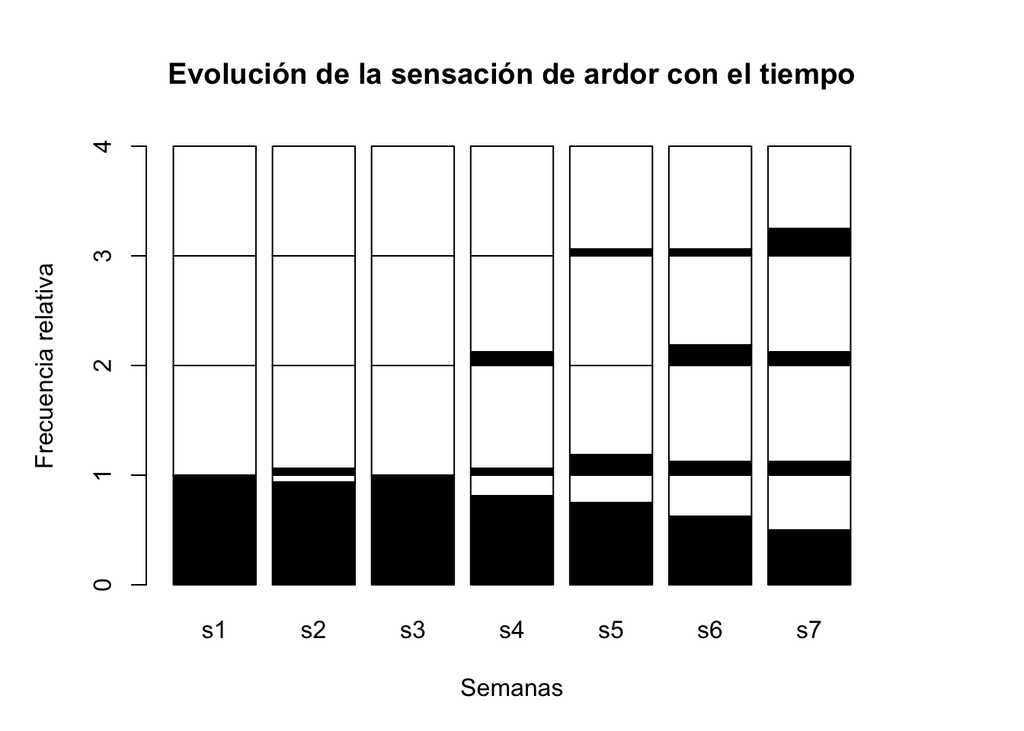

```r
# Generación de gráfico para evaluar la sensación de ardor con el tiempo

par(mar = c(5, 5, 5, 5))
original <- barplot(data,
        ylim=c(0,4),
        main="Evolución de la sensación de ardor con el tiempo",
        xlab='Semanas',
        ylab='Frecuencia relativa',
        col = c ("black", "white")
)
```

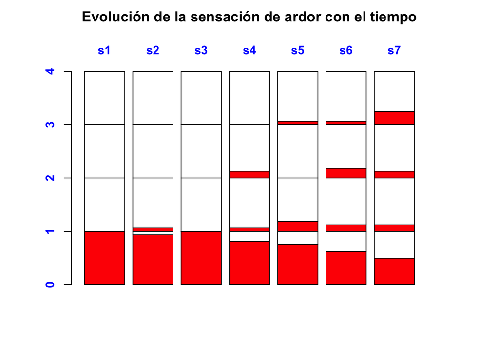

```r
# Generación de gráfico para evaluar la sensación de ardor con el tiempo con los cambios solicitados

# Amplia el margen de la hoja del gráfico
par(mar = c(5, 5, 5, 5))
cambios <- barplot(data,
        ylim=c(0,4),
        xaxt = 'n',
        col = c ("red", "white"),
        col.axis = "blue",
        font.axis = 2,


)

title("Evolución de la sensación de ardor con el tiempo", line = 3.5)
# Asigna los númeroas de las semanas a la parte superior del gráfico
axis(3, at = seq(from = 0.7, to = 7.9,by = 1.2),labels = c("s1", "s2", "s3", "s4","s5", "s6", "s7"),
     col.axis = "blue", font.axis = 2, tick = FALSE)
```